# Overview of the tidySingleCellExperiment package

Stefano Mangiola

27 July 2023

#### Package

tidySingleCellExperiment 1.11.4

# Introduction

`tidySingleCellExperiment` provides a bridge between Bioconductor single-cell packages (Amezquita et al. 2019) and the *tidyverse* (Wickham et al. 2019). It creates an invisible layer that enables viewing the Bioconductor *SingleCellExperiment* object as a *tidyverse* `tibble`, and provides `SingleCellExperiment`-compatible *dplyr*, *tidyr*, *ggplot2* and *plotly* functions (see Table 1). This allows users to get the best of both Bioconductor and *tidyverse* worlds.

Table 1: Available `tidySingleCellExperiment` functions and utilities.

| All functions compatible with `SingleCellExperiment`s | After all, a `tidySingleCellExperiment` is a `SingleCellExperiment`, just better! |
| --- | --- |
| *tidyverse* |  |
| `dplyr` | All `tibble`-compatible functions (e.g., `select()`) |
| `tidyr` | All `tibble`-compatible functions (e.g., `pivot_longer()`) |
| `ggplot2` | Plotting with `ggplot()` |
| `plotly` | Plotting with `plot_ly()` |
| **Utilities** |  |
| `tidy()` | Add an invisible `tidySingleCellExperiment` layer over a `SingleCellExperiment` object |
| `as_tibble()` | Convert cell-wise information to a `tbl_df` |
| `join_features()` | Add feature-wise information; returns a `tbl_df` |
| `aggregate_cells()` | Aggregate feature abundances as pseudobulks; returns a `SummarizedExperiment` |

# Installation

```r
if (!requireNamespace("BiocManager", quietly=TRUE))
    install.packages("BiocManager")

BiocManager::install("tidySingleCellExperiment")
```

Load libraries used in this vignette.

```r
# Bioconductor single-cell packages
library(scran)
library(scater)
library(igraph)
library(celldex)
library(SingleR)
library(SingleCellSignalR)

# Tidyverse-compatible packages
library(purrr)
library(GGally)
library(ggplot2)
library(tidyHeatmap)

# Both
library(tidySingleCellExperiment)

# Other
library(Matrix)
library(dittoSeq)
```

# 1 Creating a `tidySingleCellExperiment` – the best of both worlds!

This is a `SingleCellExperiment` object but it is evaluated as a tibble. So it is compatible both with `SingleCellExperiment` and *tidyverse*.

```r
pbmc_small_tidy <- tidySingleCellExperiment::pbmc_small
```

**It looks like a `tibble`…**

```r
pbmc_small_tidy
```

```
## # A SingleCellExperiment-tibble abstraction: 80 × 17
## # Features=230 | Cells=80 | Assays=counts, logcounts
##    .cell orig.ident nCount_RNA nFeature_RNA RNA_snn_res.0.8 letter.idents groups
##    <chr> <fct>           <dbl>        <int> <fct>           <fct>         <chr>
##  1 ATGC… SeuratPro…         70           47 0               A             g2
##  2 CATG… SeuratPro…         85           52 0               A             g1
##  3 GAAC… SeuratPro…         87           50 1               B             g2
##  4 TGAC… SeuratPro…        127           56 0               A             g2
##  5 AGTC… SeuratPro…        173           53 0               A             g2
##  6 TCTG… SeuratPro…         70           48 0               A             g1
##  7 TGGT… SeuratPro…         64           36 0               A             g1
##  8 GCAG… SeuratPro…         72           45 0               A             g1
##  9 GATA… SeuratPro…         52           36 0               A             g1
## 10 AATG… SeuratPro…        100           41 0               A             g1
## # ℹ 70 more rows
## # ℹ 10 more variables: RNA_snn_res.1 <fct>, file <chr>, ident <fct>,
## #   PC_1 <dbl>, PC_2 <dbl>, PC_3 <dbl>, PC_4 <dbl>, PC_5 <dbl>, tSNE_1 <dbl>,
## #   tSNE_2 <dbl>
```

**…but it is a `SingleCellExperiment` after all!**

```r
counts(pbmc_small_tidy)[1:5, 1:4]
```

```
## 5 x 4 sparse Matrix of class "dgCMatrix"
##         ATGCCAGAACGACT CATGGCCTGTGCAT GAACCTGATGAACC TGACTGGATTCTCA
## MS4A1                .              .              .              .
## CD79B                1              .              .              .
## CD79A                .              .              .              .
## HLA-DRA              .              1              .              .
## TCL1A                .              .              .              .
```

# 2 Annotation polishing

We may have a column that contains the directory each run was taken from, such as the “file” column in `pbmc_small_tidy`.

```r
pbmc_small_tidy$file[1:5]
```

```
## [1] "../data/sample2/outs/filtered_feature_bc_matrix/"
## [2] "../data/sample1/outs/filtered_feature_bc_matrix/"
## [3] "../data/sample2/outs/filtered_feature_bc_matrix/"
## [4] "../data/sample2/outs/filtered_feature_bc_matrix/"
## [5] "../data/sample2/outs/filtered_feature_bc_matrix/"
```

We may want to extract the run/sample name out of it into a separate column. The *tidyverse* function `extract()` can be used to convert a character column into multiple columns using regular expression groups.

```r
# Create sample column
pbmc_small_polished <-
    pbmc_small_tidy %>%
    extract(file, "sample", "../data/([a-z0-9]+)/outs.+", remove=FALSE)

# Reorder to have sample column up front
pbmc_small_polished %>%
    select(sample, everything())
```

```
## # A SingleCellExperiment-tibble abstraction: 80 × 18
## # Features=230 | Cells=80 | Assays=counts, logcounts
##    .cell sample orig.ident nCount_RNA nFeature_RNA RNA_snn_res.0.8 letter.idents
##    <chr> <chr>  <fct>           <dbl>        <int> <fct>           <fct>
##  1 ATGC… sampl… SeuratPro…         70           47 0               A
##  2 CATG… sampl… SeuratPro…         85           52 0               A
##  3 GAAC… sampl… SeuratPro…         87           50 1               B
##  4 TGAC… sampl… SeuratPro…        127           56 0               A
##  5 AGTC… sampl… SeuratPro…        173           53 0               A
##  6 TCTG… sampl… SeuratPro…         70           48 0               A
##  7 TGGT… sampl… SeuratPro…         64           36 0               A
##  8 GCAG… sampl… SeuratPro…         72           45 0               A
##  9 GATA… sampl… SeuratPro…         52           36 0               A
## 10 AATG… sampl… SeuratPro…        100           41 0               A
## # ℹ 70 more rows
## # ℹ 11 more variables: groups <chr>, RNA_snn_res.1 <fct>, file <chr>,
## #   ident <fct>, PC_1 <dbl>, PC_2 <dbl>, PC_3 <dbl>, PC_4 <dbl>, PC_5 <dbl>,
## #   tSNE_1 <dbl>, tSNE_2 <dbl>
```

# 3 Preliminary plots

Set colours and theme for plots.

```r
# Use colourblind-friendly colours
friendly_cols <- dittoSeq::dittoColors()

# Set theme
custom_theme <- list(
    scale_fill_manual(values=friendly_cols),
    scale_color_manual(values=friendly_cols),
    theme_bw() + theme(
        aspect.ratio=1,
        legend.position="bottom",
        axis.line=element_line(),
        text=element_text(size=12),
        panel.border=element_blank(),
        strip.background=element_blank(),
        panel.grid.major=element_line(linewidth=0.2),
        panel.grid.minor=element_line(linewidth=0.1),
        axis.title.x=element_text(margin=margin(t=10, r=10, b=10, l=10)),
        axis.title.y=element_text(margin=margin(t=10, r=10, b=10, l=10))))
```

We can treat `pbmc_small_polished` as a `tibble` for plotting.

Here we plot number of features per cell.

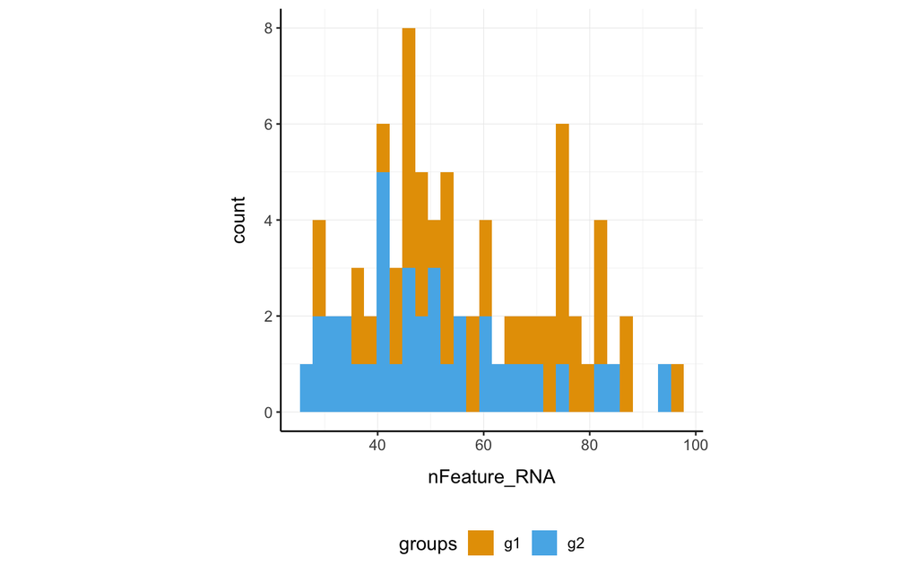

```r
pbmc_small_polished %>%
    ggplot(aes(nFeature_RNA, fill=groups)) +
    geom_histogram() +
    custom_theme
```

Here we plot total features per cell.

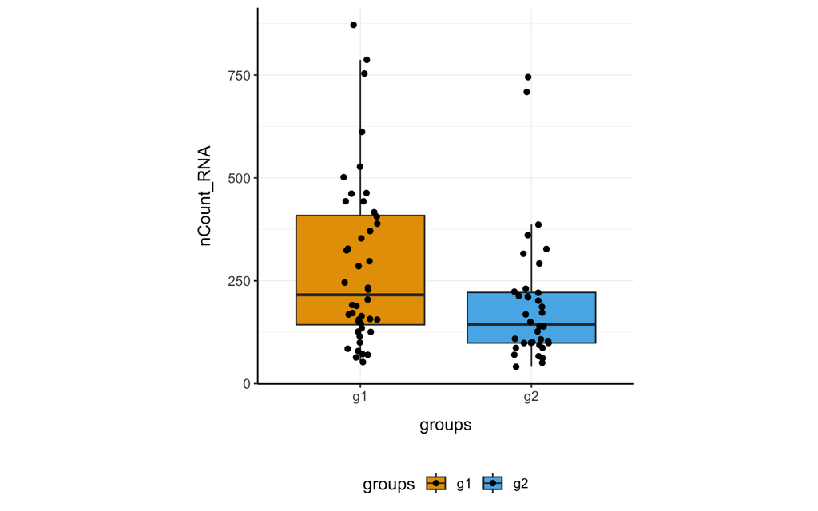

```r
pbmc_small_polished %>%
    ggplot(aes(groups, nCount_RNA, fill=groups)) +
    geom_boxplot(outlier.shape=NA) +
    geom_jitter(width=0.1) +
    custom_theme
```

Here we plot abundance of two features for each group.

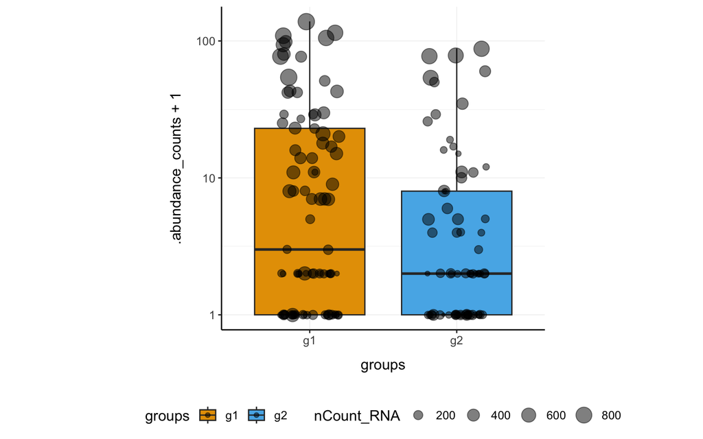

```r
pbmc_small_polished %>%
    join_features(features=c("HLA-DRA", "LYZ")) %>%
    ggplot(aes(groups, .abundance_counts + 1, fill=groups)) +
    geom_boxplot(outlier.shape=NA) +
    geom_jitter(aes(size=nCount_RNA), alpha=0.5, width=0.2) +
    scale_y_log10() +
    custom_theme
```

# 4 Preprocessing

We can also treat `pbmc_small_polished` as a `SingleCellExperiment` object and proceed with data processing with Bioconductor packages, such as *scran* (Lun, Bach, and Marioni 2016) and *scater* (McCarthy et al. 2017).

```r
# Identify variable genes with scran
variable_genes <-
    pbmc_small_polished %>%
    modelGeneVar() %>%
    getTopHVGs(prop=0.1)

# Perform PCA with scater
pbmc_small_pca <-
    pbmc_small_polished %>%
    runPCA(subset_row=variable_genes)

pbmc_small_pca
```

```
## # A SingleCellExperiment-tibble abstraction: 80 × 18
## # Features=230 | Cells=80 | Assays=counts, logcounts
##    .cell orig.ident nCount_RNA nFeature_RNA RNA_snn_res.0.8 letter.idents groups
##    <chr> <fct>           <dbl>        <int> <fct>           <fct>         <chr>
##  1 ATGC… SeuratPro…         70           47 0               A             g2
##  2 CATG… SeuratPro…         85           52 0               A             g1
##  3 GAAC… SeuratPro…         87           50 1               B             g2
##  4 TGAC… SeuratPro…        127           56 0               A             g2
##  5 AGTC… SeuratPro…        173           53 0               A             g2
##  6 TCTG… SeuratPro…         70           48 0               A             g1
##  7 TGGT… SeuratPro…         64           36 0               A             g1
##  8 GCAG… SeuratPro…         72           45 0               A             g1
##  9 GATA… SeuratPro…         52           36 0               A             g1
## 10 AATG… SeuratPro…        100           41 0               A             g1
## # ℹ 70 more rows
## # ℹ 11 more variables: RNA_snn_res.1 <fct>, file <chr>, sample <chr>,
## #   ident <fct>, PC1 <dbl>, PC2 <dbl>, PC3 <dbl>, PC4 <dbl>, PC5 <dbl>,
## #   tSNE_1 <dbl>, tSNE_2 <dbl>
```

If a *tidyverse*-compatible package is not included in the `tidySingleCellExperiment` collection, we can use `as_tibble()` to permanently convert a `tidySingleCellExperiment` into a `tibble`.

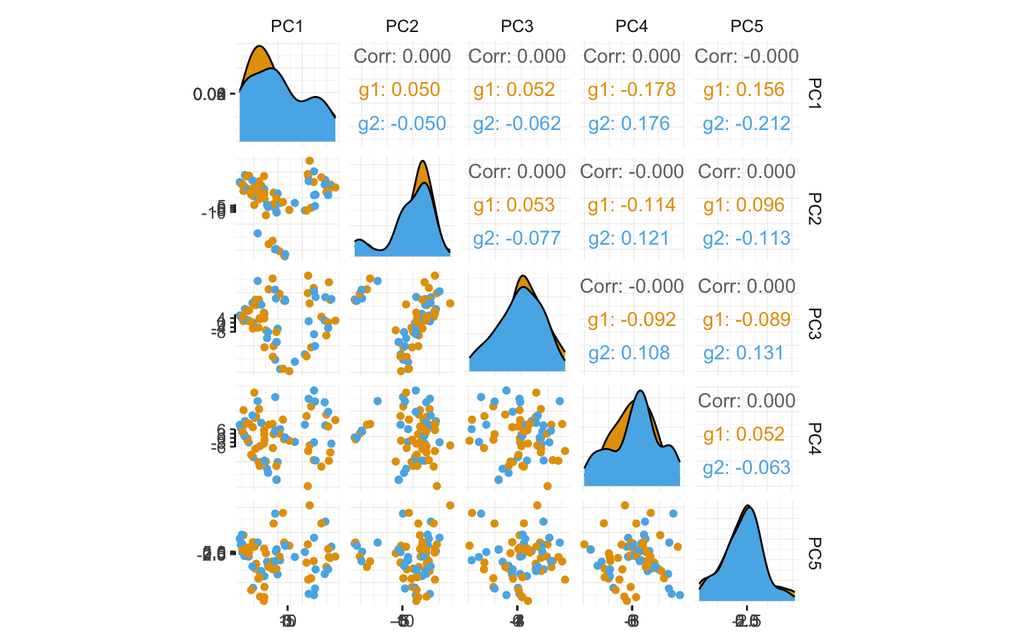

```r
# Create pairs plot with 'GGally'
pbmc_small_pca %>%
    as_tibble() %>%
    select(contains("PC"), everything()) %>%
    GGally::ggpairs(columns=1:5, aes(colour=groups)) +
    custom_theme
```

# 5 Clustering

We can proceed with cluster identification with *scran*.

```r
pbmc_small_cluster <- pbmc_small_pca

# Assign clusters to the 'colLabels'
# of the 'SingleCellExperiment' object
colLabels(pbmc_small_cluster) <-
    pbmc_small_pca %>%
    buildSNNGraph(use.dimred="PCA") %>%
    igraph::cluster_walktrap() %$%
    membership %>%
    as.factor()

# Reorder columns
pbmc_small_cluster %>%
    select(label, everything())
```

```
## # A SingleCellExperiment-tibble abstraction: 80 × 19
## # Features=230 | Cells=80 | Assays=counts, logcounts
##    .cell  label orig.ident nCount_RNA nFeature_RNA RNA_snn_res.0.8 letter.idents
##    <chr>  <fct> <fct>           <dbl>        <int> <fct>           <fct>
##  1 ATGCC… 2     SeuratPro…         70           47 0               A
##  2 CATGG… 2     SeuratPro…         85           52 0               A
##  3 GAACC… 2     SeuratPro…         87           50 1               B
##  4 TGACT… 1     SeuratPro…        127           56 0               A
##  5 AGTCA… 2     SeuratPro…        173           53 0               A
##  6 TCTGA… 2     SeuratPro…         70           48 0               A
##  7 TGGTA… 1     SeuratPro…         64           36 0               A
##  8 GCAGC… 2     SeuratPro…         72           45 0               A
##  9 GATAT… 2     SeuratPro…         52           36 0               A
## 10 AATGT… 2     SeuratPro…        100           41 0               A
## # ℹ 70 more rows
## # ℹ 12 more variables: groups <chr>, RNA_snn_res.1 <fct>, file <chr>,
## #   sample <chr>, ident <fct>, PC1 <dbl>, PC2 <dbl>, PC3 <dbl>, PC4 <dbl>,
## #   PC5 <dbl>, tSNE_1 <dbl>, tSNE_2 <dbl>
```

And interrogate the output as if it was a regular `tibble`.

```r
# Count number of cells for each cluster per group
pbmc_small_cluster %>%
    count(groups, label)
```

```
## # A tibble: 8 × 3
##   groups label     n
##   <chr>  <fct> <int>
## 1 g1     1        12
## 2 g1     2        14
## 3 g1     3        14
## 4 g1     4         4
## 5 g2     1        10
## 6 g2     2        11
## 7 g2     3        10
## 8 g2     4         5
```

We can identify and visualise cluster markers combining `SingleCellExperiment`, *tidyverse* functions and *tidyHeatmap* (Mangiola and Papenfuss 2020).

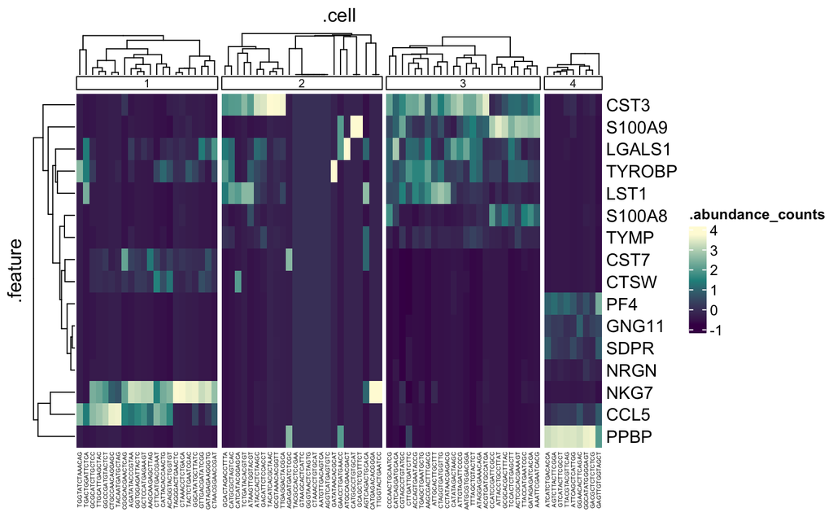

```r
# Identify top 10 markers per cluster
marker_genes <-
    pbmc_small_cluster %>%
    findMarkers(groups=pbmc_small_cluster$label) %>%
    as.list() %>%
    map(~ .x %>%
        head(10) %>%
        rownames()) %>%
    unlist()

# Plot heatmap
pbmc_small_cluster %>%
    join_features(features=marker_genes) %>%
    group_by(label) %>%
    heatmap(
        .row=.feature, .column=.cell,
        .value=.abundance_counts, scale="column")
```

# 6 Reduce dimensions

We can calculate the first 3 UMAP dimensions using *scater*.

```r
pbmc_small_UMAP <-
    pbmc_small_cluster %>%
    runUMAP(ncomponents=3)
```

And we can plot the result in 3D using *plotly*.

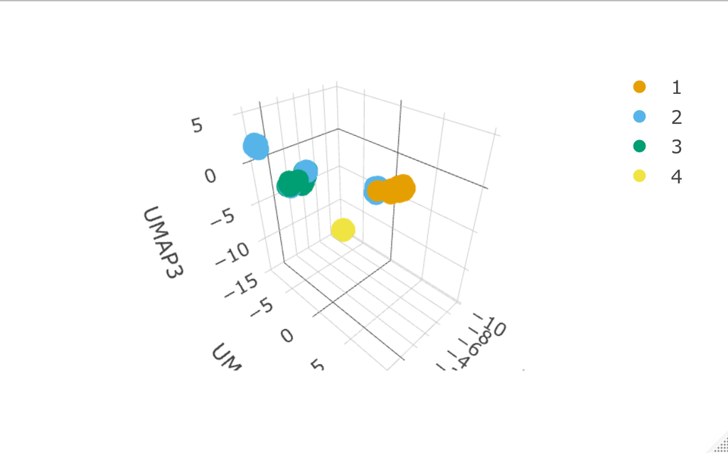

plotly screenshot

```r
pbmc_small_UMAP %>%
    plot_ly(
        x=~`UMAP1`,
        y=~`UMAP2`,
        z=~`UMAP3`,
        color=~label,
        colors=friendly_cols[1:4])
```

# 7 Cell type prediction

We can infer cell type identities using *SingleR* (Aran et al. 2019) and manipulate the output using *tidyverse*.

```r
# Get cell type reference data
blueprint <- celldex::BlueprintEncodeData()

# Infer cell identities
cell_type_df <-
    logcounts(pbmc_small_UMAP) %>%
    Matrix::Matrix(sparse = TRUE) %>%
    SingleR::SingleR(
        ref=blueprint,
        labels=blueprint$label.main,
        method="single") %>%
    as.data.frame() %>%
    as_tibble(rownames="cell") %>%
    select(cell, first.labels)
```

```r
# Join UMAP and cell type info
pbmc_small_cell_type <-
    pbmc_small_UMAP %>%
    left_join(cell_type_df, by="cell")

# Reorder columns
pbmc_small_cell_type %>%
    select(cell, first.labels, everything())
```

```
## # A SingleCellExperiment-tibble abstraction: 80 × 23
## # Features=230 | Cells=80 | Assays=counts, logcounts
##    cell          first.labels orig.ident nCount_RNA nFeature_RNA RNA_snn_res.0.8
##    <chr>         <chr>        <fct>           <dbl>        <int> <fct>
##  1 ATGCCAGAACGA… CD4+ T-cells SeuratPro…         70           47 0
##  2 CATGGCCTGTGC… CD8+ T-cells SeuratPro…         85           52 0
##  3 GAACCTGATGAA… CD8+ T-cells SeuratPro…         87           50 1
##  4 TGACTGGATTCT… CD4+ T-cells SeuratPro…        127           56 0
##  5 AGTCAGACTGCA… CD4+ T-cells SeuratPro…        173           53 0
##  6 TCTGATACACGT… CD4+ T-cells SeuratPro…         70           48 0
##  7 TGGTATCTAAAC… CD4+ T-cells SeuratPro…         64           36 0
##  8 GCAGCTCTGTTT… CD4+ T-cells SeuratPro…         72           45 0
##  9 GATATAACACGC… CD4+ T-cells SeuratPro…         52           36 0
## 10 AATGTTGACAGT… CD4+ T-cells SeuratPro…        100           41 0
## # ℹ 70 more rows
## # ℹ 17 more variables: letter.idents <fct>, groups <chr>, RNA_snn_res.1 <fct>,
## #   file <chr>, sample <chr>, ident <fct>, label <fct>, PC1 <dbl>, PC2 <dbl>,
## #   PC3 <dbl>, PC4 <dbl>, PC5 <dbl>, tSNE_1 <dbl>, tSNE_2 <dbl>, UMAP1 <dbl>,
## #   UMAP2 <dbl>, UMAP3 <dbl>
```

We can easily summarise the results. For example, we can see how cell type classification overlaps with cluster classification.

```r
# Count number of cells for each cell type per cluster
pbmc_small_cell_type %>%
    count(label, first.labels)
```

```
## # A tibble: 11 × 3
##    label first.labels     n
##    <fct> <chr>        <int>
##  1 1     CD4+ T-cells     2
##  2 1     CD8+ T-cells     8
##  3 1     NK cells        12
##  4 2     B-cells         10
##  5 2     CD4+ T-cells     6
##  6 2     CD8+ T-cells     2
##  7 2     Macrophages      1
##  8 2     Monocytes        6
##  9 3     Macrophages      1
## 10 3     Monocytes       23
## 11 4     Erythrocytes     9
```

We can easily reshape the data for building information-rich faceted plots.

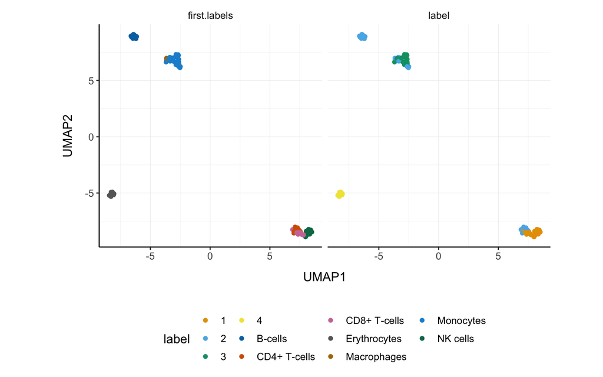

```r
pbmc_small_cell_type %>%
    # Reshape and add classifier column
    pivot_longer(
        cols=c(label, first.labels),
        names_to="classifier", values_to="label") %>%
    # UMAP plots for cell type and cluster
    ggplot(aes(UMAP1, UMAP2, color=label)) +
    facet_wrap(~classifier) +
    geom_point() +
    custom_theme
```

We can easily plot gene correlation per cell category, adding multi-layer annotations.

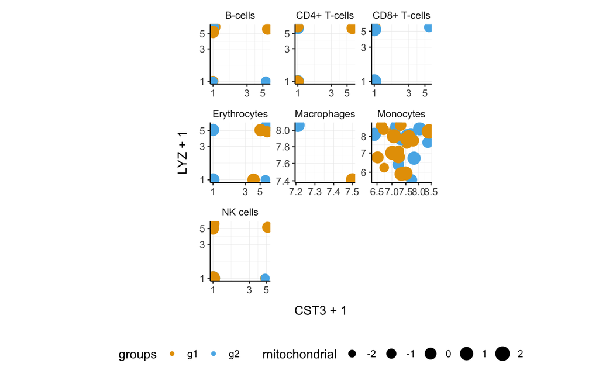

```r
pbmc_small_cell_type %>%
    # Add some mitochondrial abundance values
    mutate(mitochondrial=rnorm(dplyr::n())) %>%
    # Plot correlation
    join_features(features=c("CST3", "LYZ"), shape="wide") %>%
    ggplot(aes(CST3+1, LYZ+1, color=groups, size=mitochondrial)) +
    facet_wrap(~first.labels, scales="free") +
    geom_point() +
    scale_x_log10() +
    scale_y_log10() +
    custom_theme
```

# 8 Nested analyses

A powerful tool we can use with `tidySingleCellExperiment` is *tidyverse*’s `nest()`. We can easily perform independent analyses on subsets of the dataset. First, we classify cell types into lymphoid and myeloid, and then `nest()` based on the new classification.

```r
pbmc_small_nested <-
    pbmc_small_cell_type %>%
    filter(first.labels != "Erythrocytes") %>%
    mutate(cell_class=if_else(
        first.labels %in% c("Macrophages", "Monocytes"),
        true="myeloid", false="lymphoid")) %>%
    nest(data=-cell_class)

pbmc_small_nested
```

```
## # A tibble: 2 × 2
##   cell_class data
##   <chr>      <list>
## 1 lymphoid   <SnglCllE[,40]>
## 2 myeloid    <SnglCllE[,31]>
```

Now we can independently for the lymphoid and myeloid subsets (i) find variable features, (ii) reduce dimensions, and (iii) cluster using both tidyverse and SingleCellExperiment seamlessly.

```r
pbmc_small_nested_reanalysed <-
    pbmc_small_nested %>%
    mutate(data=map(data, ~ {
        # feature selection
        variable_genes <- .x %>%
            modelGeneVar() %>%
            getTopHVGs(prop=0.3)
        # dimension reduction
        .x <- .x %>%
            runPCA(subset_row=variable_genes) %>%
            runUMAP(ncomponents=3)
        # clustering
        colLabels(.x) <- .x %>%
            buildSNNGraph(use.dimred="PCA") %>%
            cluster_walktrap() %$%
            membership %>%
            as.factor()
        return(.x)
    }))
pbmc_small_nested_reanalysed
```

```
## # A tibble: 2 × 2
##   cell_class data
##   <chr>      <list>
## 1 lymphoid   <SnglCllE[,40]>
## 2 myeloid    <SnglCllE[,31]>
```

We can then `unnest()` and plot the new classification.

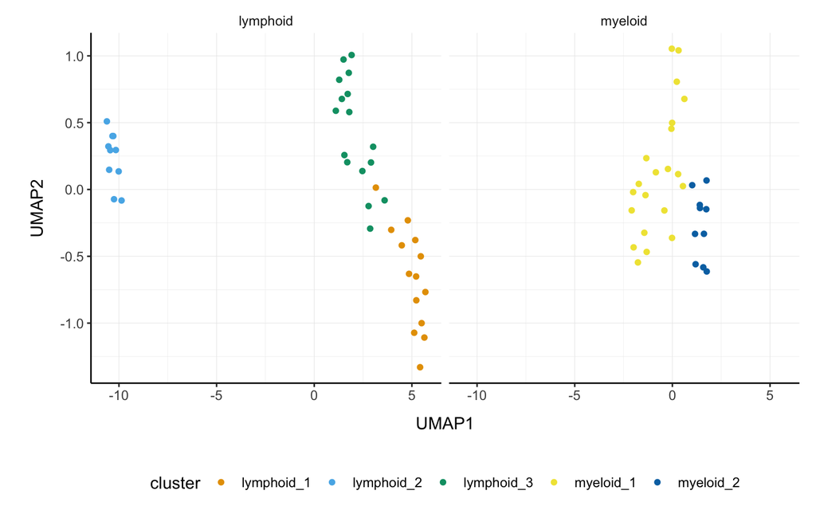

```r
pbmc_small_nested_reanalysed %>%
    # Convert to 'tibble', else 'SingleCellExperiment'
    # drops reduced dimensions when unifying data sets.
    mutate(data=map(data, ~as_tibble(.x))) %>%
    unnest(data) %>%
    # Define unique clusters
    unite("cluster", c(cell_class, label), remove=FALSE) %>%
    # Plotting
    ggplot(aes(UMAP1, UMAP2, color=cluster)) +
    facet_wrap(~cell_class) +
    geom_point() +
    custom_theme
```

We can perform a large number of functional analyses on data subsets. For example, we can identify intra-sample cell-cell interactions using *SingleCellSignalR* (Cabello-Aguilar et al. 2020), and then compare whether interactions are stronger or weaker across conditions. The code below demonstrates how this analysis could be performed. It won’t work with this small example dataset as we have just two samples (one for each condition). But some example output is shown below and you can imagine how you can use tidyverse on the output to perform t-tests and visualisation.

```r
pbmc_small_nested_interactions <-
    pbmc_small_nested_reanalysed %>%
    # Unnest based on cell category
    unnest(data) %>%
    # Create unambiguous clusters
    mutate(integrated_clusters=first.labels %>% as.factor() %>% as.integer()) %>%
    # Nest based on sample
    tidySingleCellExperiment::nest(data=-sample) %>%
    tidySingleCellExperiment::mutate(interactions=map(data, ~ {
        # Produce variables. Yuck!
        cluster <- colData(.x)$integrated_clusters
        data <- data.frame(assay(.x) %>% as.matrix())
        # Ligand/Receptor analysis using 'SingleCellSignalR'
        data %>%
            cell_signaling(genes=rownames(data), cluster=cluster) %>%
            inter_network(data=data, signal=., genes=rownames(data), cluster=cluster) %$%
            `individual-networks` %>%
            map_dfr(~ bind_rows(as_tibble(.x)))
    }))

pbmc_small_nested_interactions %>%
    select(-data) %>%
    unnest(interactions)
```

If the dataset was not so small, and interactions could be identified, you would see something like below.

```r
tidySingleCellExperiment::pbmc_small_nested_interactions
```

```
## # A tibble: 100 × 9
##    sample  ligand          receptor ligand.name receptor.name origin destination
##    <chr>   <chr>           <chr>    <chr>       <chr>         <chr>  <chr>
##  1 sample1 cluster 1.PTMA  cluster… PTMA        VIPR1         clust… cluster 2
##  2 sample1 cluster 1.B2M   cluster… B2M         KLRD1         clust… cluster 2
##  3 sample1 cluster 1.IL16  cluster… IL16        CD4           clust… cluster 2
##  4 sample1 cluster 1.HLA-B cluster… HLA-B       KLRD1         clust… cluster 2
##  5 sample1 cluster 1.CALM1 cluster… CALM1       VIPR1         clust… cluster 2
##  6 sample1 cluster 1.HLA-E cluster… HLA-E       KLRD1         clust… cluster 2
##  7 sample1 cluster 1.GNAS  cluster… GNAS        VIPR1         clust… cluster 2
##  8 sample1 cluster 1.B2M   cluster… B2M         HFE           clust… cluster 2
##  9 sample1 cluster 1.PTMA  cluster… PTMA        VIPR1         clust… cluster 3
## 10 sample1 cluster 1.CALM1 cluster… CALM1       VIPR1         clust… cluster 3
## # ℹ 90 more rows
## # ℹ 2 more variables: interaction.type <chr>, LRscore <dbl>
```

# 9 Aggregating cells

Sometimes, it is necessary to aggregate the gene-transcript abundance from a group of cells into a single value. For example, when comparing groups of cells across different samples with fixed-effect models.

In `tidySingleCellExperiment`, cell aggregation can be achieved using `aggregate_cells()`, which will return an object of class *SummarizedExperiment*.

```r
pbmc_small_tidy %>%
  aggregate_cells(groups, assays="counts")
```

```
## class: SummarizedExperiment
## dim: 230 2
## metadata(0):
## assays(1): counts
## rownames(230): ACAP1 ACRBP ... ZNF330 ZNF76
## rowData names(1): feature
## colnames(2): g1 g2
## colData names(4): groups .aggregated_cells orig.ident file
```

```
## R Under development (unstable) (2023-03-29 r84123)
## Platform: x86_64-apple-darwin17.0 (64-bit)
## Running under: macOS Big Sur ... 10.16
##
## Matrix products: default
## BLAS:   /Library/Frameworks/R.framework/Versions/4.4/Resources/lib/libRblas.0.dylib
## LAPACK: /Library/Frameworks/R.framework/Versions/4.4/Resources/lib/libRlapack.dylib;  LAPACK version 3.11.0
##
## locale:
## [1] en_US.UTF-8/en_US.UTF-8/en_US.UTF-8/C/en_US.UTF-8/en_US.UTF-8
##
## time zone: Europe/Zurich
## tzcode source: internal
##
## attached base packages:
```

[output cut: 77 more lines]

# References

Amezquita, Robert A, Aaron TL Lun, Etienne Becht, Vince J Carey, Lindsay N Carpp, Ludwig Geistlinger, Federico Martini, et al. 2019. “Orchestrating Single-Cell Analysis with Bioconductor.” *Nature Methods*, 1–9.

Aran, Dvir, Agnieszka P Looney, Leqian Liu, Esther Wu, Valerie Fong, Austin Hsu, Suzanna Chak, et al. 2019. “Reference-Based Analysis of Lung Single-Cell Sequencing Reveals a Transitional Profibrotic Macrophage.” *Nature Immunology* 20 (2): 163–72.

Cabello-Aguilar, Simon, Mélissa Alame, Fabien Kon-Sun-Tack, Caroline Fau, Matthieu Lacroix, and Jacques Colinge. 2020. “SingleCellSignalR: Inference of Intercellular Networks from Single-Cell Featureomics.” *Nucleic Acids Research* 48 (10): e55–55.

Lun, Aaron TL, Karsten Bach, and John C Marioni. 2016. “Pooling Across Cells to Normalize Single-Cell RNA Sequencing Data with Many Zero Counts.” *Genome Biology* 17 (1): 75.

Mangiola, Stefano, and Anthony T Papenfuss. 2020. “tidyHeatmap: An r Package for Modular Heatmap Production Based on Tidy Principles.” *Journal of Open Source Software* 5 (52): 2472.

McCarthy, Davis J, Kieran R Campbell, Aaron TL Lun, and Quin F Wills. 2017. “Scater: Pre-Processing, Quality Control, Normalization and Visualization of Single-Cell RNA-Seq Data in r.” *Bioinformatics* 33 (8): 1179–86.

Wickham, Hadley, Mara Averick, Jennifer Bryan, Winston Chang, Lucy D’Agostino McGowan, Romain François, Garrett Grolemund, et al. 2019. “Welcome to the Tidyverse.” *Journal of Open Source Software* 4 (43): 1686.